# Basics of R Markdown

Nathaniel Phillips

This template will show you the basics of an R Markdown document. R Markdown is a simple markup language that allows you to easily construct all kinds of documents, from reports, to web pages, to APA style documents. R Markdown documents have the .Rmd suffix. You can create a new R Markdown document in RStudio by clicking File – New File – R Markdown…

# What is Markdown?

Markdown is a combination of regular text (like this), combined with *tags* that change the way the text is formatted. For example, to make text *italic* you surround it with one asterix. To make text **bold**, you surround it with two asterices. To create section headings, you use hashtags #.

# Font formats: Italic, bold, and headers

To make headers in Markdown, use the # pound symbol at the beginning of a line

To make text *italic*, use a single * before and after the text.

To make text **bold**, use a double ** before and after the text.

# This is a 1st header

## This is a 2nd header

### This is a 3rd level header

# Bullets

To make a numbered bullet list, just use numbers

1. First element
2. Second element
3. Third element

To make a non-numbered bullet list, use dashes

- First element
- Second element
- Third element

# Markdown text vs. R Code

Markdown separates regular text from R code. Unless you use a *code chunk*, Markdown will treat all your text as regular text. For example, when I write the following lines:

1 + 1 hist(ChickWeight$weight)

Markdown just thinks that I’m writing text, not R code.

To evaluate R code in a Markdown document, you need to put the R code in a *code chunk*. Here’s how a code chunklooks

```r
# This is a code chunk. Everything here will be interpreted as R code
#  R will evalaluate the code in this chunk and print the result

1 + 1
```

```
## [1] 2
```

As you can see, code chunks in RStudio are highlighed with a gray background. Everything you put in this chunk will be evaluated by R Markdown as R code when you *Knit* the document.

1. Use the Command-Alt-I shortcut on Mac.
2. Click the “insert new code chunk” button on the top right hand of this panel. It looks like a green square with an arrow.

## R Code Chunk options

You can add arguments at the start of code chunks to change the code is evaluated and presented. Here are the most common:

### echo = FALSE

By default, Markdown will repeat (aka, echo) your R code in your final output. However, if you don’t wnat it to do this, add the echo = F argument.

In the following code, I will write some comments and calculate the mean weight of chickens in the ChickWeight dataset. Because I include the echo = F argument at the top of the chunk, the chunk will only print the result in the final output, not the original R code:

```
## [1] 121.8183
```

If I do not include the echo = F argument, R will print the original code AND the result

```r
# Now R will copy the code and give the result because I did not include echo = F

# What is the mean weight of chickens?

mean(ChickWeight$weight)
```

```
## [1] 121.8183
```

### eval = FALSE

If you include the eval = FALSE argument, R will NOT evaluate code in a chunk.

```r
# Because I included eval = FALSE at the beginning of this chunk, R will NOT evaluate the code
#  However, because I did not include echo = F, it will still copy the code

1 + 1
sd(ChickWeight$weight)
```

If I include BOTH echo = FALSE, and eval = FALSE, R will neither copy nor evaluate the code:

## fig.width, fig.height

If you generate a plot in a chunk, you can change its size with fig.width and fig.height

The following chunk will print a small figure as I set fig.width = 2 and fig.height = 2

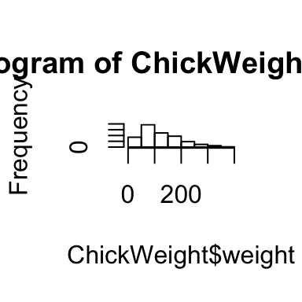

```r
hist(ChickWeight$weight)
```

The following chunk will print a large figure as I set fig.width = 7, fig.height = 7

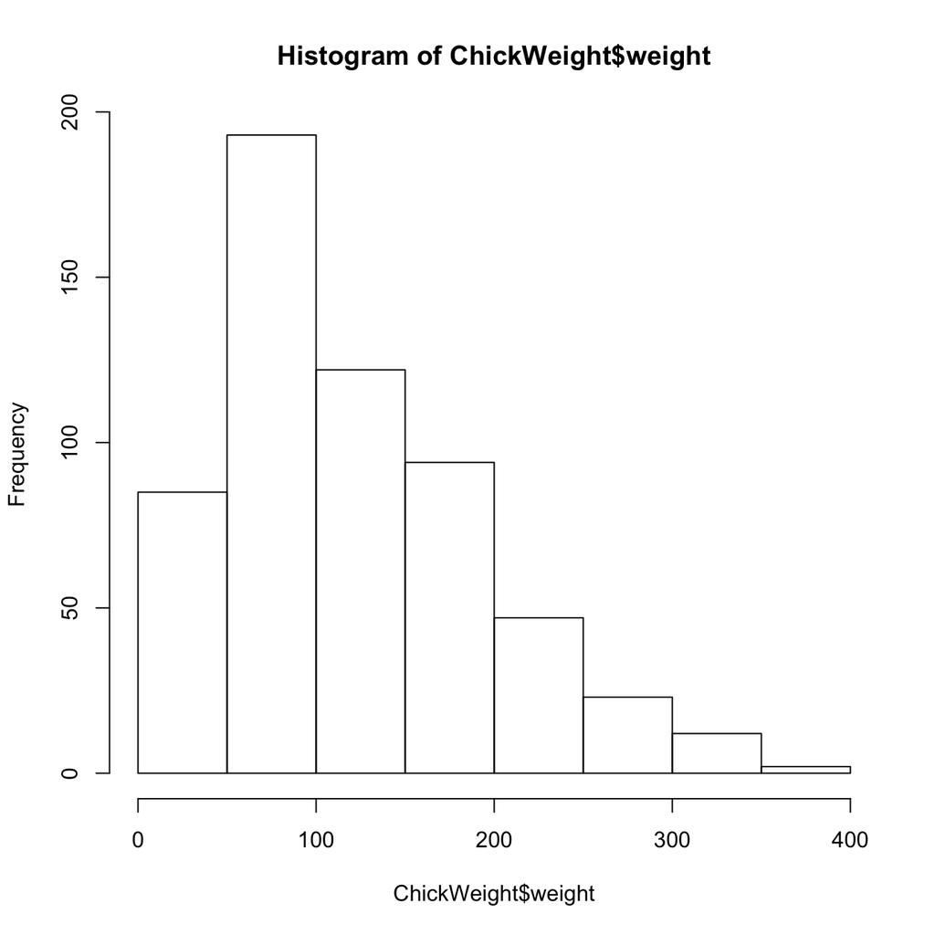

```r
hist(ChickWeight$weight)
```

# Minichunks

A mini-chunk looks like this 2 (in the final document, you’ll only see the result of the minichunk):

For example, I can write: “The mean weight of chickens was 122.” When the document is created, R will replace the r code in the mini-chunk with the result of the R command.

You can refer to objects you create in regular chunks in minichunks. For example, I’ll create a chunk that defines several objects (specifically diet.1.mean, diet.4.mean, etc.) which calculate descriptive statistics of Chickens on different diets from the ChickWeight dataframe:

```r
diet.1.mean <- round(mean(ChickWeight$weight[ChickWeight$Diet == 1]), 2)
diet.4.mean <- round(mean(ChickWeight$weight[ChickWeight$Diet == 4]), 2)

diet.1.sd <- round(sd(ChickWeight$weight[ChickWeight$Diet == 1]), 2)
diet.4.sd <- round(sd(ChickWeight$weight[ChickWeight$Diet == 4]), 2)
```

Now that the objects are defined, I can use them in a mini-chunk:

- I measured the weight of several chickens on different dients. The chickens in diet 1 had a mean weight of 102.65 (standard deviation = 56.66). In contrast, chickens on diet 4 had a mean weight of 135.26 (standard deviation = 68.83).

# Knitting a document

To create an HTML (or Word or Latex) document from RMarkdown, you need to *Knit* the document. Knitting a document simply means taking all the text and code and creating a nicely formatted document.

To Knit a document (html, word, or latex) from your markdown file, do one of the following

1. Mac: Command-Shift-K shortcut
2. Click the “Knit” button at the top of this window. It will have a picture of a ball of yarn.

## Loading libraries

If you use a package in your code, you *must* explicitly load the package in your Markdown document using library() before using the package. If you don’t, Markdown won’t know which packages you’re using and the code won’t work.

```r
# ALWAYS load packages explicitly at the beginning of any markdown document

library("yarrr")
```

## Warning! If your R code has ANY errors, the document will not knit!

-If your R code (in any standard chunks or mini-chunks) contains R errors, the document will not knit!

For example, the following chunk has a syntax error. If I tried to knit this document with eval = T, I would get an error

```r
# This text is commented, it is fine

This text is NOT commented, R thinks it is R code and will freak out if I try to knit the document.
Thanksfully, I included the eval = F argument for this chunk, so R will just ignore it.
```

If your document does not knit, you need to go through your code chunk by chunk and find the error!